# Sparkify Project Workspace

This workspace contains a tiny subset (128MB) of the full dataset available (12GB). Feel free to use this workspace to build your project, or to explore a smaller subset with Spark before deploying your cluster on the cloud. Instructions for setting up your Spark cluster is included in the last lesson of the Extracurricular Spark Course content.

You can follow the steps below to guide your data analysis and model building portion of this project.

```python
# import libraries
from pyspark.sql import SparkSession
from pyspark.sql.functions import avg, stddev, col, concat, desc, explode, lit, min, max, split, udf, sum, regexp_replace, rand
from pyspark.sql.types import IntegerType, StringType

from pyspark.ml import Pipeline
from pyspark.ml.classification import DecisionTreeClassifier, GBTClassifier, LogisticRegression, MultilayerPerceptronClassifier,LinearSVC, RandomForestClassifier
from pyspark.ml.evaluation import BinaryClassificationEvaluator, MulticlassClassificationEvaluator
from pyspark.ml.feature import CountVectorizer, IDF, Normalizer, PCA, RegexTokenizer, StandardScaler, StopWordsRemover, StringIndexer, VectorAssembler, IndexToString, MinMaxScaler
from pyspark.ml.tuning import CrossValidator, ParamGridBuilder

import time
import re
import datetime
import pickle
import matplotlib.pyplot as plt
from pyspark.sql import Window
%matplotlib inline
```

```python
# create a Spark session
spark = SparkSession.builder \
    .master("local") \
    .appName("Sparkify Project") \
    .getOrCreate()

spark.conf.set("spark.sql.execution.arrow.pyspark.enabled", "true")
spark.conf.set("spark.sql.execution.arrow.enabled", "true")
```

# Load and Clean Dataset

In this workspace, the mini-dataset file is `mini_sparkify_event_data.json`. Load and clean the dataset, checking for invalid or missing data - for example, records without userids or sessionids.

```python
stack_overflow_data = 'mini_sparkify_event_data.json'
df = spark.read.json(stack_overflow_data)
df.persist()
```

```
DataFrame[artist: string, auth: string, firstName: string, gender: string, itemInSession: bigint, lastName: string, length: double, level: string, location: string, method: string, page: string, registration: bigint, sessionId: bigint, song: string, status: bigint, ts: bigint, userAgent: string, use…
```

Create table for sql manipulation

```python
df.createOrReplaceTempView("user_log_table")
```

# Exploratory Data Analysis

When you're working with the full dataset, perform EDA by loading a small subset of the data and doing basic manipulations within Spark. In this workspace, you are already provided a small subset of data you can explore.

```python
df.show()
```

```
+--------------------+---------+---------+------+-------------+--------+---------+-----+--------------------+------+---------------+-------------+---------+--------------------+------+-------------+--------------------+------+
|              artist|     auth|firstName|gender|itemInSession|lastName|   length|level|            location|method|           page| registration|sessionId|                song|status|           ts|           userAgent|userId|
+--------------------+---------+---------+------+-------------+--------+---------+-----+--------------------+------+---------------+-------------+---------+--------------------+------+-------------+--------------------+------+
|      Martha Tilston|Logged In|    Colin|     M|           50| Freeman|277.89016| paid|     Bakersfield, CA|   PUT|       NextSong|1538173362000|       29|           Rockpools|   200|1538352117000|Mozilla/5.0 (Wind...|    30|
|    Five Iron Frenzy|Logged In|    Micah|     M|           79|    Long|236.09424| free|Boston-Cambridge-...|   PUT|       NextSong|1538331630000|        8|              Canada|   200|1538352180000|"Mozilla/5.0 (Win...|     9|
|        Adam Lambert|Logged In|    Colin|     M|           51| Freeman| 282.8273| paid|     Bakersfield, CA|   PUT|       NextSong|1538173362000|       29|   Time For Miracles|   200|1538352394000|Mozilla/5.0 (Wind...|    30|
|              Enigma|Logged In|    Micah|     M|           80|    Long|262.71302| free|Boston-Cambridge-...|   PUT|       NextSong|1538331630000|        8|Knocking On Forbi...|   200|1538352416000|"Mozilla/5.0 (Win...|     9|
|           Daft Punk|Logged In|    Colin|     M|           52| Freeman|223.60771| paid|     Bakersfield, CA|   PUT|       NextSong|1538173362000|       29|Harder Better Fas...|   200|1538352676000|Mozilla/5.0 (Wind...|    30|
|The All-American ...|Logged In|    Micah|     M|           81|    Long|208.29995| free|Boston-Cambridge-...|   PUT|       NextSong|1538331630000|        8|      Don't Leave Me|   200|1538352678000|"Mozilla/5.0 (Win...|     9|
|The Velvet Underg...|Logged In|    Micah|     M|           82|    Long|260.46649| free|Boston-Cambridge-...|   PUT|       NextSong|1538331630000|        8|         Run Run Run|   200|1538352886000|"Mozilla/5.0 (Win...|     9|
|        Starflyer 59|Logged In|    Colin|     M|           53| Freeman|185.44281| paid|     Bakersfield, CA|   PUT|       NextSong|1538173362000|       29|Passengers (Old A...|   200|1538352899000|Mozilla/5.0 (Wind...|    30|
|                null|Logged In|    Colin|     M|           54| Freeman|     null| paid|     Bakersfield, CA|   PUT|Add to Playlist|1538173362000|       29|                null|   200|1538352905000|Mozilla/5.0 (Wind...|    30|
|            Frumpies|Logged In|    Colin|     M|           55| Freeman|134.47791| paid|     Bakersfield, CA|   PUT|       NextSong|1538173362000|       29|          Fuck Kitty|   200|1538353084000|Mozilla/5.0 (Wind...|    30|
|        Britt Nicole|Logged In|    Micah|     M|           83|    Long| 229.8771| free|Boston-Cambridge-...|   PUT|       NextSong|1538331630000|        8|   Walk On The Water|   200|1538353146000|"Mozilla/5.0 (Win...|     9|
|                null|Logged In|    Micah|     M|           84|    Long|     null| free|Boston-Cambridge-...|   GET|    Roll Advert|1538331630000|        8|                null|   200|1538353150000|"Mozilla/5.0 (Win...|     9|
|Edward Sharpe & T...|Logged In|    Colin|     M|           56| Freeman|223.58159| paid|     Bakersfield, CA|   PUT|       NextSong|1538173362000|       29|                Jade|   200|1538353218000|Mozilla/5.0 (Wind...|    30|
|               Tesla|Logged In|    Micah|     M|           85|    Long|201.06404| free|Boston-Cambridge-...|   PUT|       NextSong|1538331630000|        8|      Gettin' Better|   200|1538353375000|"Mozilla/5.0 (Win...|     9|
|                null|Logged In|    Micah|     M|           86|    Long|     null| free|Boston-Cambridge-...|   PUT|      Thumbs Up|1538331630000|        8|                null|   307|1538353376000|"Mozilla/5.0 (Win...|     9|
|         Stan Mosley|Logged In|    Colin|     M|           57| Freeman|246.69995| paid|     Bakersfield, CA|   PUT|       NextSong|1538173362000|       29|   So-Called Friends|   200|1538353441000|Mozilla/5.0 (Wind...|    30|
|Florence + The Ma...|Logged In|    Micah|     M|           87|    Long|168.64608| free|Boston-Cambridge-...|   PUT|       NextSong|1538331630000|        8| You've Got The Love|   200|1538353576000|"Mozilla/5.0 (Win...|     9|
|   Tokyo Police Club|Logged In|  Ashlynn|     F|            0|Williams| 166.1122| free|     Tallahassee, FL|   PUT|       NextSong|1537365219000|      217|Citizens Of Tomorrow|   200|1538353668000|"Mozilla/5.0 (Mac...|    74|
|             Orishas|Logged In|    Colin|     M|           58| Freeman|222.22322| paid|     Bakersfield, CA|   PUT|       NextSong|1538173362000|       29|           Represent|   200|1538353687000|Mozilla/5.0 (Wind...|    30|
|             Ratatat|Logged In|    Micah|     M|           88|    Long|229.77261| free|Boston-Cambridge-...|   PUT|       NextSong|1538331630000|        8|              Swisha|   200|1538353744000|"Mozilla/5.0 (Win...|     9|
+--------------------+---------+---------+------+-------------+--------+---------+-----+--------------------+------+---------------+-------------+---------+--------------------+------+-------------+--------------------+------+
only showing top 20 rows
```

### Observe Gender

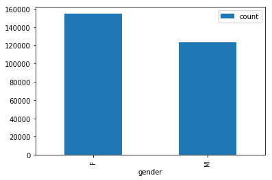

```python
df_gender = df.dropDuplicates()\
    .groupBy('gender')\
    .count()\
    .toPandas()
df_gender.index = df_gender.gender
df_gender.plot.bar()
```

### Observe account types

```python
df.dropDuplicates()\
    .groupBy('level')\
    .count()\
    .show()
```

```
+-----+------+
|level| count|
+-----+------+
| free| 58338|
| paid|228162|
+-----+------+
```

```python
spark.sql('''
        SELECT auth,COUNT(DISTINCT userId) AS user_counts
        FROM user_log_table
        GROUP BY auth
        ORDER BY user_counts DESC
''').show()
```

```
+----------+-----------+
|      auth|user_counts|
+----------+-----------+
| Logged In|        225|
| Cancelled|         52|
|Logged Out|          1|
|     Guest|          1|
+----------+-----------+
```

there are two types of the accounts are existed: free and paid

### Observe auth column

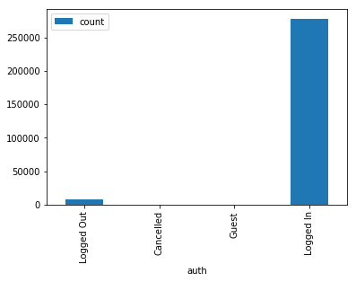

```python
df_auth = df.dropDuplicates()\
    .groupBy('auth')\
    .count()\
    .toPandas()
df_auth.index = df_auth.auth
df_auth.plot.bar()
```

### Observe Method column

```python
df.dropDuplicates()\
    .groupBy('method')\
    .count()\
    .show()
```

```
+------+------+
|method| count|
+------+------+
|   PUT|261064|
|   GET| 25436|
+------+------+
```

two types of method: put and get which could be used as a features for classification

### Observe Page column

```
+--------------------+------+
|                page| count|
+--------------------+------+
|              Cancel|    52|
|    Submit Downgrade|    63|
|         Thumbs Down|  2546|
|                Home| 14457|
|           Downgrade|  2055|
|         Roll Advert|  3933|
|              Logout|  3226|
|       Save Settings|   310|
|Cancellation Conf...|    52|
|               About|   924|
| Submit Registration|     5|
|            Settings|  1514|
|               Login|  3241|
|            Register|    18|
|     Add to Playlist|  6526|
|          Add Friend|  4277|
|            NextSong|228108|
|           Thumbs Up| 12551|
|                Help|  1726|
|             Upgrade|   499|
+--------------------+------+
only showing top 20 rows
```

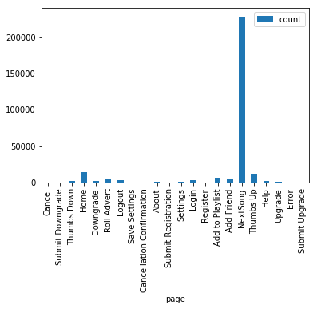

```python
df.dropDuplicates()\
    .groupBy('page')\
    .count()\
    .show()
df_page = df.dropDuplicates()\
    .groupBy('page')\
    .count()\
    .toPandas()
df_page.index = df_page.page
df_page.plot.bar()
```

page column reflect multiple actions of the users

### User Agent

```python
df.dropDuplicates()\
    .groupBy('userAgent')\
    .count()\
    .show(truncate=False)
```

```
+-------------------------------------------------------------------------------------------------------------------------------------------+-----+
|userAgent                                                                                                                                  |count|
+-------------------------------------------------------------------------------------------------------------------------------------------+-----+
|"Mozilla/5.0 (Macintosh; Intel Mac OS X 10_8_5) AppleWebKit/537.36 (KHTML, like Gecko) Chrome/36.0.1985.143 Safari/537.36"                 |240  |
|"Mozilla/5.0 (Windows NT 5.1) AppleWebKit/537.36 (KHTML, like Gecko) Chrome/36.0.1985.143 Safari/537.36"                                   |5238 |
|Mozilla/5.0 (X11; Ubuntu; Linux i686; rv:31.0) Gecko/20100101 Firefox/31.0                                                                 |62   |
|"Mozilla/5.0 (Macintosh; Intel Mac OS X 10_9_4) AppleWebKit/537.36 (KHTML, like Gecko) Chrome/36.0.1985.125 Safari/537.36"                 |18448|
|"Mozilla/5.0 (Macintosh; Intel Mac OS X 10_9_4) AppleWebKit/537.36 (KHTML, like Gecko) Chrome/35.0.1916.153 Safari/537.36"                 |1262 |
|Mozilla/5.0 (Macintosh; Intel Mac OS X 10.7; rv:31.0) Gecko/20100101 Firefox/31.0                                                          |2442 |
|Mozilla/5.0 (Windows NT 6.1; WOW64; rv:30.0) Gecko/20100101 Firefox/30.0                                                                   |3214 |
|Mozilla/5.0 (Windows NT 6.3; WOW64; rv:31.0) Gecko/20100101 Firefox/31.0                                                                   |5989 |
|Mozilla/5.0 (compatible; MSIE 9.0; Windows NT 6.1; WOW64; Trident/5.0)                                                                     |8624 |
|"Mozilla/5.0 (Windows NT 6.3; WOW64) AppleWebKit/537.36 (KHTML, like Gecko) Chrome/36.0.1985.143 Safari/537.36"                            |7624 |
|Mozilla/5.0 (Macintosh; Intel Mac OS X 10.9; rv:31.0) Gecko/20100101 Firefox/31.0                                                          |10300|
|"Mozilla/5.0 (Windows NT 5.1) AppleWebKit/537.36 (KHTML, like Gecko) Chrome/36.0.1985.125 Safari/537.36"                                   |2168 |
|null                                                                                                                                       |8346 |
|"Mozilla/5.0 (iPhone; CPU iPhone OS 7_1_1 like Mac OS X) AppleWebKit/537.51.2 (KHTML, like Gecko) Version/7.0 Mobile/11D201 Safari/9537.53"|1976 |
|"Mozilla/5.0 (Windows NT 6.1; WOW64) AppleWebKit/537.36 (KHTML, like Gecko) Chrome/36.0.1985.125 Safari/537.36"                            |15395|
|Mozilla/5.0 (Windows NT 6.1; WOW64; rv:31.0) Gecko/20100101 Firefox/31.0                                                                   |16700|
|Mozilla/5.0 (compatible; MSIE 9.0; Windows NT 6.1; Trident/5.0)                                                                            |1245 |
|Mozilla/5.0 (compatible; MSIE 10.0; Windows NT 6.1; WOW64; Trident/6.0)                                                                    |815  |
|"Mozilla/5.0 (Macintosh; Intel Mac OS X 10_8_5) AppleWebKit/537.36 (KHTML, like Gecko) Chrome/37.0.2062.94 Safari/537.36"                  |235  |
|"Mozilla/5.0 (Macintosh; Intel Mac OS X 10_9_2) AppleWebKit/537.75.14 (KHTML, like Gecko) Version/7.0.3 Safari/537.75.14"                  |512  |
+-------------------------------------------------------------------------------------------------------------------------------------------+-----+
only showing top 20 rows
```

```python
df.select('userAgent').distinct().count()
```

```
57
```

userAgent include the os system and softwares; it has 57 types combinations so this would be considered as a categorical features

### UserId

```python
df.select('userId','auth').sort('userId').show(5,truncate=False)
```

```
+------+----------+
|userId|auth      |
+------+----------+
|      |Logged Out|
|      |Logged Out|
|      |Logged Out|
|      |Logged Out|
|      |Logged Out|
+------+----------+
only showing top 5 rows
```

The data include a lot of empty userId which is for the user logged out/guests. These unknown records are difficult to track and they cannot be used to predict the downgrade. Therefore, the empty records will be removed.

```python
df = df.where(df['userId']!='')
```

```python
df.dropDuplicates()\
    .groupBy('auth')\
    .count()\
    .show()
```

```
+---------+------+
|     auth| count|
+---------+------+
|Cancelled|    52|
|Logged In|278102|
+---------+------+
```

```python
df.where(df.auth=='Cancelled').select('page').show(truncate=False)
```

```
+-------------------------+
|page                     |
+-------------------------+
|Cancellation Confirmation|
|Cancellation Confirmation|
|Cancellation Confirmation|
|Cancellation Confirmation|
|Cancellation Confirmation|
|Cancellation Confirmation|
|Cancellation Confirmation|
|Cancellation Confirmation|
|Cancellation Confirmation|
|Cancellation Confirmation|
|Cancellation Confirmation|
|Cancellation Confirmation|
|Cancellation Confirmation|
|Cancellation Confirmation|
|Cancellation Confirmation|
|Cancellation Confirmation|
|Cancellation Confirmation|
|Cancellation Confirmation|
|Cancellation Confirmation|
|Cancellation Confirmation|
+-------------------------+
only showing top 20 rows
```

'Cancelled' in 'auth' column is equivalent to the 'Cancellation Confirmation' in 'page' column

### Define Churn

Once you've done some preliminary analysis, create a column `Churn` to use as the label for your model. I suggest using the `Cancellation Confirmation` events to define your churn, which happen for both paid and free users. As a bonus task, you can also look into the `Downgrade` events.

```python
#define the flag event udf to transform event to 0 or 1
#flag_event = udf(lambda x : 1 if x in {'Cancellation Confirmation', 'Downgrade'} else 0, IntegerType())
flag_event = udf(lambda x : 1 if x in {'Cancellation Confirmation'} else 0, IntegerType())
#define the current churn or not state
df = df.withColumn('Churn',flag_event('page'))
df.where(df.Churn == 1).show()
```

```
+------+---------+---------+------+-------------+---------+------+-----+--------------------+------+--------------------+-------------+---------+----+------+-------------+--------------------+------+-----+
|artist|     auth|firstName|gender|itemInSession| lastName|length|level|            location|method|                page| registration|sessionId|song|status|           ts|           userAgent|userId|Churn|
+------+---------+---------+------+-------------+---------+------+-----+--------------------+------+--------------------+-------------+---------+----+------+-------------+--------------------+------+-----+
|  null|Cancelled|   Adriel|     M|          104|  Mendoza|  null| paid|  Kansas City, MO-KS|   GET|Cancellation Conf...|1535623466000|      514|null|   200|1538943990000|"Mozilla/5.0 (Mac...|    18|    1|
|  null|Cancelled|    Diego|     M|           56|    Mckee|  null| paid|Phoenix-Mesa-Scot...|   GET|Cancellation Conf...|1537167593000|      540|null|   200|1539033046000|"Mozilla/5.0 (iPh...|    32|    1|
|  null|Cancelled|    Mason|     M|           10|     Hart|  null| free|  Corpus Christi, TX|   GET|Cancellation Conf...|1533157139000|      174|null|   200|1539318918000|"Mozilla/5.0 (Mac...|   125|    1|
|  null|Cancelled|Alexander|     M|          332|   Garcia|  null| paid|Indianapolis-Carm...|   GET|Cancellation Conf...|1536817381000|      508|null|   200|1539375441000|Mozilla/5.0 (Wind...|   105|    1|
|  null|Cancelled|    Kayla|     F|          273|  Johnson|  null| paid|Philadelphia-Camd...|   GET|Cancellation Conf...|1538333829000|      797|null|   200|1539465584000|Mozilla/5.0 (Wind...|    17|    1|
|  null|Cancelled|    Molly|     F|           29| Harrison|  null| free|Virginia Beach-No...|   GET|Cancellation Conf...|1534255113000|      843|null|   200|1539588854000|"Mozilla/5.0 (Mac...|   143|    1|
|  null|Cancelled|     Alex|     M|          145|    Hogan|  null| paid|Denver-Aurora-Lak...|   GET|Cancellation Conf...|1535066380000|      842|null|   200|1539729037000|Mozilla/5.0 (Wind...|   101|    1|
|  null|Cancelled|    Davis|     M|           34|     Wang|  null| paid|           Flint, MI|   GET|Cancellation Conf...|1538289776000|      802|null|   200|1539736161000|"Mozilla/5.0 (Win...|   129|    1|
|  null|Cancelled|  Nikolas|     M|          287|    Olsen|  null| paid|Oxnard-Thousand O...|   GET|Cancellation Conf...|1528403713000|      881|null|   200|1539759749000|Mozilla/5.0 (X11;...|   121|    1|
|  null|Cancelled|    Ethan|     M|          176|  Johnson|  null| paid|Lexington-Fayette...|   GET|Cancellation Conf...|1538080987000|      934|null|   200|1539761972000|"Mozilla/5.0 (Win...|    51|    1|
|  null|Cancelled|Christian|     M|          100| Robinson|  null| paid|       Quincy, IL-MO|   GET|Cancellation Conf...|1534942082000|     1092|null|   200|1540050556000|"Mozilla/5.0 (Win...|    87|    1|
|  null|Cancelled|    Molly|     F|           43|Patterson|  null| paid|   Memphis, TN-MS-AR|   GET|Cancellation Conf...|1535498705000|     1029|null|   200|1540062068000|Mozilla/5.0 (X11;...|   122|    1|
|  null|Cancelled|   Sophia|     F|           72|    Perry|  null| paid|Los Angeles-Long ...|   GET|Cancellation Conf...|1533885783000|     1072|null|   200|1540193374000|Mozilla/5.0 (Wind...|    12|    1|
|  null|Cancelled|    Erick|     M|           48|   Brooks|  null| paid|           Selma, AL|   GET|Cancellation Conf...|1537956751000|     1112|null|   200|1540223006000|"Mozilla/5.0 (Win...|    58|    1|
|  null|Cancelled|   Rachel|     F|           11|   Bailey|  null| paid|Albany-Schenectad...|   GET|Cancellation Conf...|1536102943000|     1059|null|   200|1540402387000|Mozilla/5.0 (Wind...|    73|    1|
|  null|Cancelled|  Jeffery|     M|           46|  Wheeler|  null| paid|         Bozeman, MT|   GET|Cancellation Conf...|1533886191000|     1324|null|   200|1540875543000|"Mozilla/5.0 (Win...|     3|    1|
|  null|Cancelled|   Sophia|     F|           18|      Key|  null| paid|Los Angeles-Long ...|   GET|Cancellation Conf...|1537679535000|     1383|null|   200|1541166424000|"Mozilla/5.0 (Mac...|   106|    1|
|  null|Cancelled|    Piper|     F|            8|  Nielsen|  null| paid|New York-Newark-J...|   GET|Cancellation Conf...|1537699856000|     1583|null|   200|1541340091000|"Mozilla/5.0 (Mac...|   103|    1|
|  null|Cancelled|   Teagan|     F|          306|  Roberts|  null| paid|New Philadelphia-...|   GET|Cancellation Conf...|1537634865000|     1519|null|   200|1541463632000|Mozilla/5.0 (Wind...|    28|    1|
|  null|Cancelled|    Alexi|     F|           42|   Warren|  null| paid|Spokane-Spokane V...|   GET|Cancellation Conf...|1532482662000|     1819|null|   200|1542051608000|Mozilla/5.0 (Wind...|    54|    1|
+------+---------+---------+------+-------------+---------+------+-----+--------------------+------+--------------------+-------------+---------+----+------+-------------+--------------------+------+-----+
only showing top 20 rows
```

### Explore Data

Once you've defined churn, perform some exploratory data analysis to observe the behavior for users who stayed vs users who churned. You can start by exploring aggregates on these two groups of users, observing how much of a specific action they experienced per a certain time unit or number of songs played.

```python
# clearly represent registration and timestamp by creating new columns
new_ts = udf(lambda x: datetime.datetime.fromtimestamp(x / 1000.0).strftime("%m-%d-%Y %H:%M:%S"))
df = df.withColumn('updated_ts', new_ts('ts'))
```

```python
ts_fun = udf(lambda x: datetime.datetime.fromtimestamp(x / 1000.0).strftime("%m-%d-%Y"))
df = df.withColumn('date', ts_fun('ts'))
```

```python
# label users who have churned
churn_window = Window.partitionBy("userId").rangeBetween(Window.unboundedPreceding, Window.unboundedFollowing)
df = df.withColumn("user_churned", sum('Churn').over(churn_window))
df.show()
```

```
+--------------------+---------+---------+------+-------------+---------+---------+-----+--------------------+------+-----------+-------------+---------+--------------------+------+-------------+--------------------+------+-----+-------------------+----------+------------+
|              artist|     auth|firstName|gender|itemInSession| lastName|   length|level|            location|method|       page| registration|sessionId|                song|status|           ts|           userAgent|userId|Churn|         updated_ts|      date|user_churned|
+--------------------+---------+---------+------+-------------+---------+---------+-----+--------------------+------+-----------+-------------+---------+--------------------+------+-------------+--------------------+------+-----+-------------------+----------+------------+
|Sleeping With Sirens|Logged In| Darianna|     F|            0|Carpenter|202.97098| free|Bridgeport-Stamfo...|   PUT|   NextSong|1538016340000|       31|Captain Tyin Knot...|   200|1539003534000|"Mozilla/5.0 (iPh...|100010|    0|10-08-2018 12:58:54|10-08-2018|           0|
|Francesca Battist...|Logged In| Darianna|     F|            1|Carpenter|196.54485| free|Bridgeport-Stamfo...|   PUT|   NextSong|1538016340000|       31|Beautiful_ Beauti...|   200|1539003736000|"Mozilla/5.0 (iPh...|100010|    0|10-08-2018 13:02:16|10-08-2018|           0|
|              Brutha|Logged In| Darianna|     F|            2|Carpenter|263.13098| free|Bridgeport-Stamfo...|   PUT|   NextSong|1538016340000|       31|          She's Gone|   200|1539003932000|"Mozilla/5.0 (iPh...|100010|    0|10-08-2018 13:05:32|10-08-2018|           0|
|                null|Logged In| Darianna|     F|            3|Carpenter|     null| free|Bridgeport-Stamfo...|   PUT|  Thumbs Up|1538016340000|       31|                null|   307|1539003933000|"Mozilla/5.0 (iPh...|100010|    0|10-08-2018 13:05:33|10-08-2018|           0|
|         Josh Ritter|Logged In| Darianna|     F|            4|Carpenter|316.23791| free|Bridgeport-Stamfo...|   PUT|   NextSong|1538016340000|       31|      Folk Bloodbath|   200|1539004195000|"Mozilla/5.0 (iPh...|100010|    0|10-08-2018 13:09:55|10-08-2018|           0|
|               LMFAO|Logged In| Darianna|     F|            5|Carpenter|183.74485| free|Bridgeport-Stamfo...|   PUT|   NextSong|1538016340000|       31|                 Yes|   200|1539004511000|"Mozilla/5.0 (iPh...|100010|    0|10-08-2018 13:15:11|10-08-2018|           0|
|         OneRepublic|Logged In| Darianna|     F|            6|Carpenter|224.67873| free|Bridgeport-Stamfo...|   PUT|   NextSong|1538016340000|       31|             Secrets|   200|1539004694000|"Mozilla/5.0 (iPh...|100010|    0|10-08-2018 13:18:14|10-08-2018|           0|
|       Dwight Yoakam|Logged In| Darianna|     F|            7|Carpenter| 239.3073| free|Bridgeport-Stamfo...|   PUT|   NextSong|1538016340000|       31|      You're The One|   200|1539004918000|"Mozilla/5.0 (iPh...|100010|    0|10-08-2018 13:21:58|10-08-2018|           0|
|                null|Logged In| Darianna|     F|            8|Carpenter|     null| free|Bridgeport-Stamfo...|   GET|Roll Advert|1538016340000|       31|                null|   200|1539004961000|"Mozilla/5.0 (iPh...|100010|    0|10-08-2018 13:22:41|10-08-2018|           0|
|      The Chordettes|Logged In| Darianna|     F|            9|Carpenter|142.41914| free|Bridgeport-Stamfo...|   PUT|   NextSong|1538016340000|       31|          Mr Sandman|   200|1539005157000|"Mozilla/5.0 (iPh...|100010|    0|10-08-2018 13:25:57|10-08-2018|           0|
|Coko featuring Ki...|Logged In| Darianna|     F|           10|Carpenter| 249.3122| free|Bridgeport-Stamfo...|   PUT|   NextSong|1538016340000|       31|           I Get Joy|   200|1539005299000|"Mozilla/5.0 (iPh...|100010|    0|10-08-2018 13:28:19|10-08-2018|           0|
|            The Cure|Logged In| Darianna|     F|           11|Carpenter| 52.27057| free|Bridgeport-Stamfo...|   PUT|   NextSong|1538016340000|       31|     The Final Sound|   200|1539005548000|"Mozilla/5.0 (iPh...|100010|    0|10-08-2018 13:32:28|10-08-2018|           0|
|                null|Logged In| Darianna|     F|           12|Carpenter|     null| free|Bridgeport-Stamfo...|   GET|Roll Advert|1538016340000|       31|                null|   200|1539005571000|"Mozilla/5.0 (iPh...|100010|    0|10-08-2018 13:32:51|10-08-2018|           0|
```

[output cut: 9 more lines]

```python
df.createOrReplaceTempView("labeled_user_log")
```

```python
df.where(df.user_churned==1).select('page','user_churned','Churn','updated_ts').show()
```

```
+--------------------+------------+-----+-------------------+
|                page|user_churned|Churn|         updated_ts|
+--------------------+------------+-----+-------------------+
|            NextSong|           1|    0|10-12-2018 04:05:44|
|            NextSong|           1|    0|10-12-2018 04:11:21|
|            NextSong|           1|    0|10-12-2018 04:15:11|
|            NextSong|           1|    0|10-12-2018 04:18:34|
|            NextSong|           1|    0|10-12-2018 04:22:04|
|            NextSong|           1|    0|10-12-2018 04:28:35|
|            NextSong|           1|    0|10-12-2018 04:32:08|
|            NextSong|           1|    0|10-12-2018 04:35:06|
|         Roll Advert|           1|    0|10-12-2018 04:35:17|
|              Cancel|           1|    0|10-12-2018 04:35:18|
|Cancellation Conf...|           1|    1|10-12-2018 04:35:18|
|                Home|           1|    0|10-01-2018 12:57:12|
|            NextSong|           1|    0|10-01-2018 12:57:29|
|            NextSong|           1|    0|10-01-2018 13:02:18|
|            NextSong|           1|    0|10-01-2018 13:06:07|
|            NextSong|           1|    0|10-01-2018 13:09:11|
|            NextSong|           1|    0|10-01-2018 13:11:35|
|            NextSong|           1|    0|10-01-2018 13:17:23|
|            NextSong|           1|    0|10-01-2018 13:21:26|
|            NextSong|           1|    0|10-01-2018 13:25:09|
+--------------------+------------+-----+-------------------+
only showing top 20 rows
```

```python
spark.sql('''
SELECT userId, page, song, artist,length,updated_ts
FROM labeled_user_log
WHERE user_churned = 1
ORDER BY userId DESC, ts DESC
''').show(10)
```

```
+------+--------------------+--------------------+------------------+---------+-------------------+
|userId|                page|                song|            artist|   length|         updated_ts|
+------+--------------------+--------------------+------------------+---------+-------------------+
|    87|Cancellation Conf...|                null|              null|     null|10-20-2018 15:49:16|
|    87|              Cancel|                null|              null|     null|10-20-2018 15:48:58|
|    87|           Downgrade|                null|              null|     null|10-20-2018 15:48:57|
|    87|            NextSong|Dissolution; The ...|            Clinic|160.57424|10-20-2018 15:47:44|
|    87|            NextSong|The Man In The Sa...|Fountains Of Wayne|160.39138|10-20-2018 15:45:04|
|    87|            NextSong|            Get Away|       Danny Gokey|242.49424|10-20-2018 15:41:02|
|    87|         Thumbs Down|                null|              null|     null|10-20-2018 15:37:26|
|    87|            NextSong|  The Authority Song|   Jimmy Eat World|217.18159|10-20-2018 15:37:25|
|    87|            NextSong|       Peligroso Pop|   Plastilina Mosh|217.25995|10-20-2018 15:33:48|
|    87|            NextSong|Chicken Fried (Al...|    Zac Brown Band|237.08689|10-20-2018 15:29:51|
+------+--------------------+--------------------+------------------+---------+-------------------+
only showing top 10 rows
```

```python
df_length=spark.sql('''
SELECT userId, date, SUM(length) sum_len
FROM labeled_user_log
WHERE user_churned = 1
GROUP BY userId, date
ORDER BY userId DESC, date DESC
''').toPandas()
```

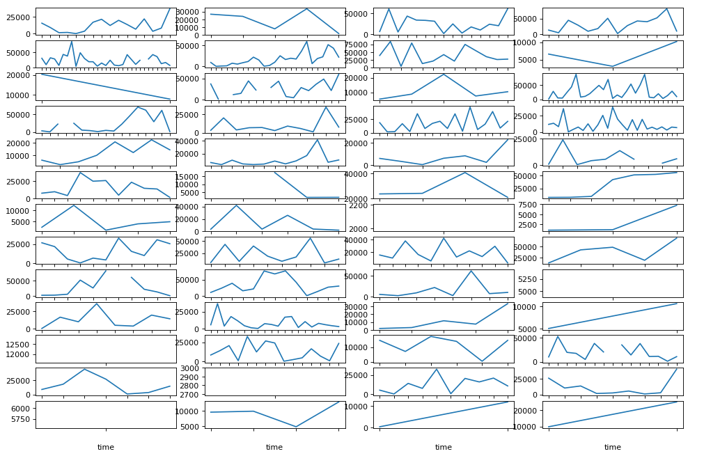

```python
plt.figure(figsize=(15, 10), dpi=80)
for i, id in enumerate(df_length['userId'].unique()):
    plt.subplot(13, 4, i + 1)
    plt.plot(df_length[df_length['userId']==id]['date'],df_length[df_length['userId']==id]['sum_len'])
    plt.xticks(color='w')
    plt.xlabel('time')
```

```python
df_thumbdown=spark.sql('''
SELECT userId, COUNT(page) thumbsdown
FROM labeled_user_log
WHERE user_churned = 1 AND page = 'Thumbs Down'
GROUP BY userId
''').toPandas()
```

```
Text(0,0.5,'counts of thumbs down')
```

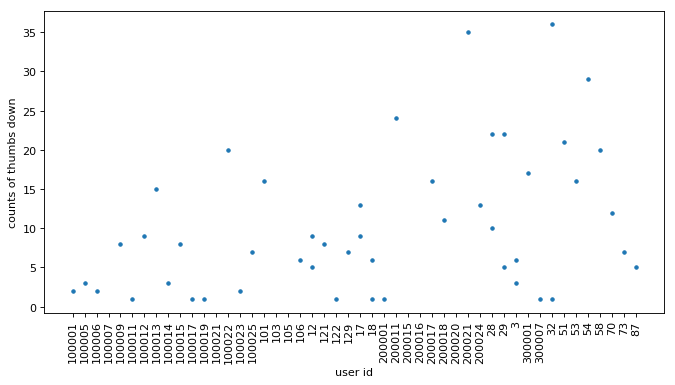

```python
plt.figure(figsize=(10, 5), dpi=80)
plt.plot(df_thumbdown['userId'],df_thumbdown['thumbsdown'],marker='.',linestyle='None')
plt.xticks(rotation=90);
plt.xlabel('user id')
plt.ylabel('counts of thumbs down')
```

# Feature Engineering

Once you've familiarized yourself with the data, build out the features you find promising to train your model on. To work with the full dataset, you can follow the following steps.

- Write a script to extract the necessary features from the smaller subset of data
- Ensure that your script is scalable, using the best practices discussed in Lesson 3
- Try your script on the full data set, debugging your script if necessary

If you are working in the classroom workspace, you can just extract features based on the small subset of data contained here. Be sure to transfer over this work to the larger dataset when you work on your Spark cluster.

### 1. User Agent

```python
indexer = StringIndexer(inputCol="userAgent", outputCol="userAgent_num")
indexed_df = indexer.fit(df).transform(df)
```

```python
indexed_df = indexed_df.withColumn("userAgent_num", indexed_df["userAgent_num"].cast(IntegerType()))
```

```python
userAgent_df = indexed_df.groupBy("userId").pivot("userAgent_num").agg(lit(1))
userAgent_df = userAgent_df.na.fill(0)
```

```python
userAgent_df.show()
```

```
+------+---+---+---+---+---+---+---+---+---+---+---+---+---+---+---+---+---+---+---+---+---+---+---+---+---+---+---+---+---+---+---+---+---+---+---+---+---+---+---+---+---+---+---+---+---+---+---+---+---+---+---+---+---+---+---+---+
|userId|  0|  1|  2|  3|  4|  5|  6|  7|  8|  9| 10| 11| 12| 13| 14| 15| 16| 17| 18| 19| 20| 21| 22| 23| 24| 25| 26| 27| 28| 29| 30| 31| 32| 33| 34| 35| 36| 37| 38| 39| 40| 41| 42| 43| 44| 45| 46| 47| 48| 49| 50| 51| 52| 53| 54| 55|
+------+---+---+---+---+---+---+---+---+---+---+---+---+---+---+---+---+---+---+---+---+---+---+---+---+---+---+---+---+---+---+---+---+---+---+---+---+---+---+---+---+---+---+---+---+---+---+---+---+---+---+---+---+---+---+---+---+
|100010|  0|  0|  0|  0|  0|  0|  0|  0|  0|  0|  0|  0|  0|  0|  1|  0|  0|  0|  0|  0|  0|  0|  0|  0|  0|  0|  0|  0|  0|  0|  0|  0|  0|  0|  0|  0|  0|  0|  0|  0|  0|  0|  0|  0|  0|  0|  0|  0|  0|  0|  0|  0|  0|  0|  0|  0|
|200002|  0|  0|  0|  0|  0|  0|  0|  0|  0|  0|  0|  0|  0|  0|  0|  0|  0|  0|  0|  0|  0|  0|  0|  0|  0|  0|  1|  0|  0|  0|  0|  0|  0|  0|  0|  0|  0|  0|  0|  0|  0|  0|  0|  0|  0|  0|  0|  0|  0|  0|  0|  0|  0|  0|  0|  0|
|   125|  0|  0|  1|  0|  0|  0|  0|  0|  0|  0|  0|  0|  0|  0|  0|  0|  0|  0|  0|  0|  0|  0|  0|  0|  0|  0|  0|  0|  0|  0|  0|  0|  0|  0|  0|  0|  0|  0|  0|  0|  0|  0|  0|  0|  0|  0|  0|  0|  0|  0|  0|  0|  0|  0|  0|  0|
|   124|  0|  0|  0|  1|  0|  0|  0|  0|  0|  0|  0|  0|  0|  0|  0|  0|  0|  0|  0|  0|  0|  0|  0|  0|  0|  0|  0|  0|  0|  0|  0|  0|  0|  0|  0|  0|  0|  0|  0|  0|  0|  0|  0|  0|  0|  0|  0|  0|  0|  0|  0|  0|  0|  0|  0|  0|
|     7|  0|  0|  0|  0|  0|  0|  0|  0|  0|  0|  0|  0|  0|  0|  0|  0|  0|  0|  0|  0|  0|  0|  0|  0|  0|  0|  0|  0|  0|  0|  0|  0|  0|  0|  0|  0|  0|  0|  0|  0|  0|  0|  0|  0|  0|  1|  0|  0|  0|  0|  0|  0|  0|  0|  0|  0|
|    51|  1|  0|  0|  0|  0|  0|  0|  0|  0|  0|  0|  0|  0|  0|  0|  0|  0|  0|  0|  0|  0|  0|  0|  0|  0|  0|  0|  0|  0|  0|  0|  0|  0|  0|  0|  0|  0|  0|  0|  0|  0|  0|  0|  0|  0|  0|  0|  0|  0|  0|  0|  0|  0|  0|  0|  0|
|    15|  1|  0|  0|  0|  0|  0|  0|  0|  0|  0|  0|  0|  0|  0|  0|  0|  0|  0|  0|  0|  0|  0|  0|  0|  0|  0|  0|  0|  0|  0|  0|  0|  0|  0|  0|  0|  0|  0|  0|  0|  0|  0|  0|  0|  0|  0|  0|  0|  0|  0|  0|  0|  0|  0|  0|  0|
|    54|  0|  0|  0|  0|  0|  0|  0|  0|  0|  0|  0|  0|  0|  0|  0|  0|  0|  0|  0|  0|  0|  1|  0|  0|  0|  0|  0|  0|  0|  0|  0|  0|  0|  0|  0|  0|  0|  0|  0|  0|  0|  0|  0|  0|  0|  0|  0|  0|  0|  0|  0|  0|  0|  0|  0|  0|
|   155|  1|  0|  0|  0|  0|  0|  0|  0|  0|  0|  0|  0|  0|  0|  0|  0|  0|  0|  0|  0|  0|  0|  0|  0|  0|  0|  0|  0|  0|  0|  0|  0|  0|  0|  0|  0|  0|  0|  0|  0|  0|  0|  0|  0|  0|  0|  0|  0|  0|  0|  0|  0|  0|  0|  0|  0|
|   132|  0|  1|  0|  0|  0|  0|  0|  0|  0|  0|  0|  0|  0|  0|  0|  0|  0|  0|  0|  0|  0|  0|  0|  0|  0|  0|  0|  0|  0|  0|  0|  0|  0|  0|  0|  0|  0|  0|  0|  0|  0|  0|  0|  0|  0|  0|  0|  0|  0|  0|  0|  0|  0|  0|  0|  0|
|   154|  1|  0|  0|  0|  0|  0|  0|  0|  0|  0|  0|  0|  0|  0|  0|  0|  0|  0|  0|  0|  0|  0|  0|  0|  0|  0|  0|  0|  0|  0|  0|  0|  0|  0|  0|  0|  0|  0|  0|  0|  0|  0|  0|  0|  0|  0|  0|  0|  0|  0|  0|  0|  0|  0|  0|  0|
|100014|  1|  0|  0|  0|  0|  0|  0|  0|  0|  0|  0|  0|  0|  0|  0|  0|  0|  0|  0|  0|  0|  0|  0|  0|  0|  0|  0|  0|  0|  0|  0|  0|  0|  0|  0|  0|  0|  0|  0|  0|  0|  0|  0|  0|  0|  0|  0|  0|  0|  0|  0|  0|  0|  0|  0|  0|
|    11|  0|  0|  0|  0|  0|  0|  0|  0|  0|  0|  0|  0|  0|  0|  0|  0|  0|  0|  0|  1|  0|  0|  0|  0|  0|  0|  0|  0|  0|  0|  0|  0|  0|  0|  0|  0|  0|  0|  0|  0|  0|  0|  0|  0|  0|  0|  0|  0|  0|  0|  0|  0|  0|  0|  0|  0|
|   101|  0|  0|  0|  0|  0|  0|  0|  0|  0|  0|  0|  0|  0|  0|  0|  0|  0|  0|  0|  0|  0|  0|  0|  0|  0|  0|  0|  0|  0|  0|  0|  0|  0|  1|  0|  0|  0|  0|  0|  0|  0|  0|  0|  0|  0|  0|  0|  0|  0|  0|  0|  0|  0|  0|  0|  0|
|   138|  0|  0|  0|  0|  0|  0|  0|  0|  0|  0|  0|  0|  0|  0|  0|  0|  0|  0|  0|  0|  0|  0|  0|  0|  0|  0|  0|  0|  1|  0|  0|  0|  0|  0|  0|  0|  0|  0|  0|  0|  0|  0|  0|  0|  0|  0|  0|  0|  0|  0|  0|  0|  0|  0|  0|  0|
|300017|  0|  0|  0|  0|  0|  0|  0|  0|  0|  0|  0|  0|  0|  0|  0|  0|  1|  0|  0|  0|  0|  0|  0|  0|  0|  0|  0|  0|  0|  0|  0|  0|  0|  0|  0|  0|  0|  0|  0|  0|  0|  0|  0|  0|  0|  0|  0|  0|  0|  0|  0|  0|  0|  0|  0|  0|
|    29|  0|  1|  0|  0|  0|  0|  0|  0|  0|  0|  0|  0|  0|  0|  0|  0|  0|  0|  0|  0|  0|  0|  0|  0|  0|  0|  0|  0|  0|  0|  0|  0|  0|  0|  0|  0|  0|  0|  0|  0|  0|  0|  0|  0|  0|  0|  0|  0|  0|  0|  0|  0|  0|  0|  0|  0|
|    69|  1|  0|  0|  0|  0|  0|  0|  0|  0|  0|  0|  0|  0|  0|  0|  0|  0|  0|  0|  0|  0|  0|  0|  0|  0|  0|  0|  0|  0|  0|  0|  0|  0|  0|  0|  0|  0|  0|  0|  0|  0|  0|  0|  0|  0|  0|  0|  0|  0|  0|  0|  0|  0|  0|  0|  0|
|100021|  0|  0|  0|  0|  0|  0|  0|  0|  0|  0|  1|  0|  0|  0|  0|  0|  0|  0|  0|  0|  0|  0|  0|  0|  0|  0|  0|  0|  0|  0|  0|  0|  0|  0|  0|  0|  0|  0|  0|  0|  0|  0|  0|  0|  0|  0|  0|  0|  0|  0|  0|  0|  0|  0|  0|  0|
|    42|  0|  0|  0|  0|  0|  0|  0|  0|  0|  0|  0|  1|  0|  0|  0|  0|  0|  0|  0|  0|  0|  0|  0|  0|  0|  0|  0|  0|  0|  0|  0|  0|  0|  0|  0|  0|  0|  0|  0|  0|  0|  0|  0|  0|  0|  0|  0|  0|  0|  0|  0|  0|  0|  0|  0|  0|
+------+---+---+---+---+---+---+---+---+---+---+---+---+---+---+---+---+---+---+---+---+---+---+---+---+---+---+---+---+---+---+---+---+---+---+---+---+---+---+---+---+---+---+---+---+---+---+---+---+---+---+---+---+---+---+---+---+
only showing top 20 rows
```

### 2. Gender

```python
gender_df = df.groupBy("userId").pivot("gender").agg(lit(1))
gender_df = gender_df.na.fill(0)
gender_df.show()
```

```
+------+---+---+
|userId|  F|  M|
+------+---+---+
|100010|  1|  0|
|200002|  0|  1|
|   125|  0|  1|
|    51|  0|  1|
|     7|  0|  1|
|   124|  1|  0|
|    15|  0|  1|
|    54|  1|  0|
|   155|  1|  0|
|100014|  0|  1|
|   154|  1|  0|
|   132|  1|  0|
|   101|  0|  1|
|    11|  1|  0|
|   138|  0|  1|
|300017|  1|  0|
|100021|  0|  1|
|    69|  1|  0|
|    29|  0|  1|
|    42|  1|  0|
+------+---+---+
only showing top 20 rows
```

### 3. Level

```python
level_df = df.groupBy("userId").pivot("level").agg(lit(1)).na.fill(0)
level_df.show()
```

```
+------+----+----+
|userId|free|paid|
+------+----+----+
|200002|   1|   1|
|100010|   1|   0|
|   125|   1|   0|
|     7|   1|   0|
|   124|   0|   1|
|    51|   0|   1|
|    54|   1|   1|
|    15|   0|   1|
|   155|   1|   1|
|   132|   1|   1|
|   154|   1|   0|
|100014|   0|   1|
|    11|   1|   1|
|   101|   1|   1|
|300017|   0|   1|
|   138|   1|   1|
|100021|   1|   0|
|    29|   1|   1|
|    69|   1|   1|
|   112|   1|   0|
+------+----+----+
only showing top 20 rows
```

```python
num_songs_df = df.select('userId', 'song').groupBy('userId').count().withColumnRenamed('count', 'num_songs')
num_songs_df.show()
```

```
+------+---------+
|userId|num_songs|
+------+---------+
|100010|      381|
|200002|      474|
|   125|       11|
|    51|     2464|
|   124|     4825|
|     7|      201|
|    54|     3437|
|    15|     2278|
|   155|     1002|
|   132|     2304|
|   154|      118|
|100014|      310|
|   101|     2149|
|    11|      848|
|   138|     2469|
|300017|     4428|
|    29|     3603|
|    69|     1342|
|100021|      319|
|    42|     4257|
+------+---------+
only showing top 20 rows
```

```python
song_length_df = df.where(df.page=='NextSong').select('userId', 'sessionId', 'length')
song_length_df = song_length_df.withColumn('hours', (song_length_df.length / 3600))
song_length_df = song_length_df.groupBy('userId','sessionId').sum('hours')
song_length_df = song_length_df.groupBy('userId').agg(avg('sum(hours)').alias('mean_hours'), stddev('sum(hours)').alias('stdev_hours')).na.fill(0)
```

```python
song_length_df.show()
```

```
+------+------------------+------------------+
|userId|        mean_hours|       stdev_hours|
+------+------------------+------------------+
|100010|2.6563848154761907|1.5940891633984364|
|200002|       4.352262775| 3.481087253628621|
|   125|0.5803091944444445|               0.0|
|    51|14.535440077777778|11.600663366034107|
|   124|10.042778698313494| 9.370878101268762|
|     7|1.5092891706349203|1.7372572756564078|
|    54| 5.645594599523808|6.7241639034102025|
|    15| 9.470389004166666| 6.159367750898716|
|   155|  9.20274499537037| 6.528671599395436|
|100014| 3.134420003703703|1.7543652306205215|
|   132| 8.387480969444443| 8.411844077944691|
|   154|1.9129651768518519|0.8567096079055881|
|   101|12.429555963055552| 14.92789006740804|
|    11| 2.772047969444445| 2.754383050218178|
|300017| 4.086552733196721|3.6120139088908414|
|   138| 9.489812643703699|11.718117293713126|
|    29| 6.164359171323531|   8.7578661203911|
|    69|  8.82913659382716| 8.270113865858235|
|100021| 3.201843091111111|3.5951139397524394|
|    42| 5.974207087601625| 4.686088669792696|
+------+------------------+------------------+
only showing top 20 rows
```

### 6. counts of ThumbsUp , ThumbsDown etc

```python
# create the event counts table
user_page_df = df.groupby('userId').pivot('page').count().na.fill(0)
# drop the labels in case of overfitting
user_page_df = user_page_df.drop(*['Cancellation Confirmation', 'Downgrade'])
```

```python
user_page_df.show()
```

```
+------+-----+----------+---------------+------+-----+----+----+------+--------+-----------+-------------+--------+----------------+--------------+-----------+---------+-------+
|userId|About|Add Friend|Add to Playlist|Cancel|Error|Help|Home|Logout|NextSong|Roll Advert|Save Settings|Settings|Submit Downgrade|Submit Upgrade|Thumbs Down|Thumbs Up|Upgrade|
+------+-----+----------+---------------+------+-----+----+----+------+--------+-----------+-------------+--------+----------------+--------------+-----------+---------+-------+
|200002|    3|         4|              8|     0|    0|   2|  20|     5|     387|          7|            0|       3|               0|             1|          6|       21|      2|
|100010|    1|         4|              7|     0|    0|   2|  11|     5|     275|         52|            0|       0|               0|             0|          5|       17|      2|
|   125|    0|         0|              0|     1|    0|   0|   0|     0|       8|          1|            0|       0|               0|             0|          0|        0|      0|
|    51|    2|        28|             52|     1|    1|  12|  75|    24|    2111|          0|            1|      12|               0|             0|         21|      100|      0|
|   124|    7|        74|            118|     0|    6|  23| 176|    59|    4079|          4|            6|      20|               0|             0|         41|      171|      0|
|     7|    0|         1|              5|     0|    1|   1|  10|     3|     150|         16|            1|       3|               0|             0|          1|        7|      2|
|    54|    5|        33|             72|     1|    1|  17| 129|    36|    2841|         47|            3|      17|               1|             1|         29|      163|      1|
|    15|    2|        31|             59|     0|    2|   8|  93|    27|    1914|          1|            2|      16|               0|             0|         14|       81|      0|
|   155|    2|        11|             24|     0|    3|   9|  30|    14|     820|          8|            0|       5|               0|             1|          3|       58|      2|
|   132|    4|        41|             38|     0|    3|  16|  83|    34|    1928|          2|            4|      17|               0|             1|         17|       96|      1|
|100014|    0|         6|              7|     1|    0|   2|   7|     3|     257|          2|            0|       1|               0|             0|          3|       17|      0|
|   154|    0|         3|              1|     0|    0|   1|   6|     2|      84|         10|            0|       0|               0|             0|          0|       11|      0|
|    11|    7|         6|             20|     0|    1|   3|  37|    14|     647|         39|            2|       6|               1|             2|          9|       40|      9|
|   101|    2|        29|             61|     1|    3|  12|  74|    24|    1797|          8|            2|       9|               0|             1|         16|       86|      1|
|   138|    8|        41|             67|     0|    1|  13|  71|    18|    2070|         17|            4|      17|               0|             1|         24|       95|      1|
|300017|    3|        63|            113|     0|    5|  27| 151|    41|    3632|         11|            3|      23|               0|             0|         28|      303|      0|
|    29|    2|        47|             89|     1|    0|  28| 121|    41|    3028|         22|            4|      19|               0|             1|         22|      154|      5|
|100021|    1|         7|              7|     1|    2|   0|  15|     7|     230|         30|            0|       0|               0|             0|          5|       11|      2|
|    69|    3|        12|             33|     0|    4|   7|  49|    10|    1125|          3|            1|       3|               0|             1|          9|       72|      1|
|    42|    6|        52|            104|     0|    7|  20| 176|    44|    3573|         10|            7|      28|               0|             1|         25|      166|      1|
+------+-----+----------+---------------+------+-----+----+----+------+--------+-----------+-------------+--------+----------------+--------------+-----------+---------+-------+
only showing top 20 rows
```

### 7. Number of artist the user follow

```python
# Number of artists the user listen to
num_artists_user_df = df.select('userId', 'artist').dropDuplicates().groupBy('userId').count().withColumnRenamed("count", "num_aritsts")
num_artists_user_df.show()
```

```
+------+-----------+
|userId|num_aritsts|
+------+-----------+
|100010|        253|
|200002|        340|
|   125|          9|
|    51|       1386|
|   124|       2233|
|     7|        143|
|    15|       1303|
|    54|       1745|
|   155|        644|
|   132|       1300|
|   154|         79|
|100014|        234|
|   101|       1242|
|    11|        535|
|   138|       1333|
|300017|       2071|
|    29|       1805|
|    69|        866|
|100021|        208|
|    42|       2074|
+------+-----------+
only showing top 20 rows
```

### 8. Sessions count per user

```python
num_sessions_user_df = df.select('userId', 'sessionId').dropDuplicates().groupby('userId').count().withColumnRenamed('count', 'num_sessions')
num_sessions_user_df.show()
```

```
+------+------------+
|userId|num_sessions|
+------+------------+
|100010|           7|
|200002|           6|
|   125|           1|
|    51|          10|
|   124|          29|
|     7|           7|
|    54|          37|
|    15|          15|
|   155|           6|
|100014|           6|
|   132|          16|
|   154|           3|
|   101|          10|
|    11|          16|
|300017|          63|
|   138|          15|
|    29|          34|
|    69|           9|
|100021|           5|
|    42|          47|
+------+------------+
only showing top 20 rows
```

### 9. The length of user's subscription

```python
# time of users registration
reg_ts = df.select('userId', 'registration').dropDuplicates().withColumnRenamed('registration', 'start')
# calculate the maximal timestamp as the end
end_ts = df.groupBy('userId').max('ts').withColumnRenamed('max(ts)', 'end')
# The difference
reg_df = reg_ts.join(end_ts,'userId')
ticks_per_day = 1000 * 60 * 60 * 24 # as the timestamp is in ticks (0.001 seconds)
# Merge in one df
reg_df = reg_df.select('userId', ((reg_df.end-reg_df.start)/ticks_per_day).alias('subscription_length'))


reg_df.show()
```

```
+------+-------------------+
|userId|subscription_length|
+------+-------------------+
|200024|  28.42769675925926|
|200025|  116.9954861111111|
|   118|  63.12707175925926|
|    28|  44.31443287037037|
|100003| 22.748113425925926|
|   122|  52.81670138888889|
|   149| 46.179710648148145|
|   111|  82.22630787037038|
|300001|  188.3117824074074|
|     3|  80.89527777777778|
|    62| 134.06662037037037|
|100017|  78.88440972222222|
|    10|  51.76265046296297|
|200010| 38.142488425925926|
|    40|  78.96927083333334|
|   131| 120.89991898148148|
|   136|  75.35636574074074|
|    75|  68.92494212962963|
|   128|  95.33168981481481|
|200019|  56.23005787037037|
+------+-------------------+
only showing top 20 rows
```

### 10. Location

```python
location_df = df.select(col('userId'),split(col("location"),",")[1]).groupBy("userId").pivot("split(location, ,)[1]").agg(lit(1))
location_df = location_df.na.fill(0)
location_df.show()
```

```
+------+---+---+---+---+---+---+---+------------+---+---+------+---+---+---------+------+---+---+------+---+------+---+------+---+------+------+------+---+---+---+------+------+---+---+---+---+---------+---+---------+---+---+------+---+------+------------+------+---+------+---+---------+------+---+-…
|userId| AK| AL| AR| AZ| CA| CO| CT| DC-VA-MD-WV| FL| GA| GA-AL| IA| IL| IL-IN-WI| IL-MO| IN| KY| KY-IN| LA| MA-NH| MD| MD-WV| MI| MN-WI| MO-IL| MO-KS| MS| MT| NC| NC-SC| NE-IA| NH| NJ| NV| NY| NY-NJ-PA| OH| OH-KY-IN| OK| OR| OR-WA| PA| PA-NJ| PA-NJ-DE-MD| RI-MA| SC| SC-NC| TN| TN-MS-AR| TN-VA| TX| …
+------+---+---+---+---+---+---+---+------------+---+---+------+---+---+---------+------+---+---+------+---+------+---+------+---+------+------+------+---+---+---+------+------+---+---+---+---+---------+---+---------+---+---+------+---+------+------------+------+---+------+---+---------+------+---+-…
|100010|  0|  0|  0|  0|  0|  0|  1|           0|  0|  0|     0|  0|  0|        0|     0|  0|  0|     0|  0|     0|  0|     0|  0|     0|     0|     0|  0|  0|  0|     0|     0|  0|  0|  0|  0|        0|  0|        0|  0|  0|     0|  0|     0|           0|     0|  0|     0|  0|        0|     0|  0| …
|200002|  0|  0|  0|  0|  0|  0|  0|           0|  0|  0|     0|  0|  0|        1|     0|  0|  0|     0|  0|     0|  0|     0|  0|     0|     0|     0|  0|  0|  0|     0|     0|  0|  0|  0|  0|        0|  0|        0|  0|  0|     0|  0|     0|           0|     0|  0|     0|  0|        0|     0|  0| …
|   125|  0|  0|  0|  0|  0|  0|  0|           0|  0|  0|     0|  0|  0|        0|     0|  0|  0|     0|  0|     0|  0|     0|  0|     0|     0|     0|  0|  0|  0|     0|     0|  0|  0|  0|  0|        0|  0|        0|  0|  0|     0|  0|     0|           0|     0|  0|     0|  0|        0|     0|  1| …
|   124|  0|  0|  0|  0|  0|  0|  0|           0|  0|  0|     0|  0|  0|        0|     0|  0|  0|     0|  0|     0|  0|     0|  0|     0|     0|     0|  0|  0|  0|     0|     0|  0|  1|  0|  0|        0|  0|        0|  0|  0|     0|  0|     0|           0|     0|  0|     0|  0|        0|     0|  0| …
|     7|  0|  0|  0|  0|  0|  0|  0|           0|  0|  0|     0|  0|  0|        0|     0|  0|  0|     0|  0|     0|  0|     0|  0|     0|     0|     0|  0|  0|  0|     0|     0|  0|  0|  0|  0|        0|  0|        0|  0|  0|     0|  0|     0|           0|     0|  0|     0|  0|        0|     0|  0| …
|    51|  0|  0|  0|  0|  0|  0|  0|           0|  0|  0|     0|  0|  0|        0|     0|  0|  1|     0|  0|     0|  0|     0|  0|     0|     0|     0|  0|  0|  0|     0|     0|  0|  0|  0|  0|        0|  0|        0|  0|  0|     0|  0|     0|           0|     0|  0|     0|  0|        0|     0|  0| …
|    54|  0|  0|  0|  0|  0|  0|  0|           0|  0|  0|     0|  0|  0|        0|     0|  0|  0|     0|  0|     0|  0|     0|  0|     0|     0|     0|  0|  0|  0|     0|     0|  0|  0|  0|  0|        0|  0|        0|  0|  0|     0|  0|     0|           0|     0|  0|     0|  0|        0|     0|  0| …
|    15|  0|  0|  0|  0|  0|  0|  0|           0|  0|  0|     0|  0|  0|        0|     0|  0|  0|     0|  0|     0|  0|     0|  0|     0|     0|     0|  0|  0|  0|     0|     0|  0|  0|  0|  0|        0|  0|        0|  0|  0|     0|  0|     0|           0|     0|  0|     0|  0|        0|     0|  0| …
|   155|  0|  0|  0|  0|  0|  0|  0|           0|  0|  0|     0|  0|  0|        0|     0|  0|  0|     0|  0|     1|  0|     0|  0|     0|     0|     0|  0|  0|  0|     0|     0|  0|  0|  0|  0|        0|  0|        0|  0|  0|     0|  0|     0|           0|     0|  0|     0|  0|        0|     0|  0| …
|   154|  0|  0|  0|  0|  0|  0|  0|           0|  0|  0|     0|  0|  0|        0|     0|  0|  0|     0|  0|     0|  0|     0|  0|     0|     0|     0|  0|  0|  0|     0|     0|  0|  0|  0|  0|        1|  0|        0|  0|  0|     0|  0|     0|           0|     0|  0|     0|  0|        0|     0|  0| …
|   132|  0|  0|  0|  0|  0|  1|  0|           0|  0|  0|     0|  0|  0|        0|     0|  0|  0|     0|  0|     0|  0|     0|  0|     0|     0|     0|  0|  0|  0|     0|     0|  0|  0|  0|  0|        0|  0|        0|  0|  0|     0|  0|     0|           0|     0|  0|     0|  0|        0|     0|  0| …
|100014|  0|  0|  0|  0|  0|  0|  0|           0|  0|  0|     0|  0|  0|        0|     0|  0|  0|     0|  0|     0|  0|     0|  0|     0|     0|     0|  0|  0|  0|     0|     0|  0|  0|  0|  0|        1|  0|        0|  0|  0|     0|  0|     0|           0|     0|  0|     0|  0|        0|     0|  0| …
|   101|  0|  0|  0|  0|  0|  1|  0|           0|  0|  0|     0|  0|  0|        0|     0|  0|  0|     0|  0|     0|  0|     0|  0|     0|     0|     0|  0|  0|  0|     0|     0|  0|  0|  0|  0|        0|  0|        0|  0|  0|     0|  0|     0|           0|     0|  0|     0|  0|        0|     0|  0| …
```

[output cut: 9 more lines]

### 11. labels

```python
# setting up the label
label = df.select('userId', col('Churn').alias('label')).dropDuplicates()
```

```python
label.groupby('label').count().show()
```

```
+-----+-----+
|label|count|
+-----+-----+
|    1|   52|
|    0|  225|
+-----+-----+
```

### Gather data

```python
# numeric features
numeric_features = num_songs_df.join(user_page_df,on='userId',how='outer')\
                            .join(song_length_df,'userId','outer') \
                            .join(num_artists_user_df,'userId','outer') \
                            .join(num_sessions_user_df,'userId','outer') \
                            .join(reg_df,'userId','outer')
assembler = VectorAssembler(inputCols=numeric_features.columns[1:], outputCol="Numerical_Features")
numeric_features = assembler.transform(numeric_features)
scaler2 = MinMaxScaler(inputCol="Numerical_Features", outputCol="Numeric_Features")
scalerModel = scaler2.fit(numeric_features)
numeric_features = scalerModel.transform(numeric_features)
numeric_features.select('Numeric_Features').show(truncate=False)
```

```
+-----------------------------------------------------------------------------------------------------------------------------------------------------------------------------------------------------------------------------------------------------------------------------------------------------------…
|Numeric_Features                                                                                                                                                                                                                                                                                           …
+-----------------------------------------------------------------------------------------------------------------------------------------------------------------------------------------------------------------------------------------------------------------------------------------------------------…
|[0.03895699148140453,0.04,0.027972027972027972,0.029166666666666667,0.0,0.0,0.043478260869565216,0.030985915492957747,0.04032258064516129,0.034004250531316414,0.40625,0.0,0.0,0.0,0.0,0.06666666666666667,0.038901601830663615,0.13333333333333333,0.12602068363101493,0.06917729681181785,0.0703191188929…
|[0.048618325368792854,0.12,0.027972027972027972,0.03333333333333333,0.0,0.0,0.043478260869565216,0.056338028169014086,0.04032258064516129,0.048006000750093765,0.0546875,0.0,0.057692307692307696,0.0,0.25,0.08,0.04805491990846682,0.13333333333333333,0.21274699079207088,0.15106570680068845,0.094888449…
|[5.194265530853937E-4,0.0,0.0,0.0,1.0,0.0,0.0,0.0,0.0,6.250781347668458E-4,0.0078125,0.0,0.0,0.0,0.0,0.0,0.0,0.0,0.019851267967557536,0.0,0.001412030499858797,0.0,0.27728682862557164]                                                                                                                    …
|[0.5006233118637025,0.28,0.5174825174825175,0.49166666666666664,0.0,0.8571428571428571,0.5,0.49577464788732395,0.47580645161290325,0.5095636954619327,0.03125,0.6,0.38461538461538464,0.0,0.0,0.5466666666666666,0.391304347826087,0.0,0.5037569830492628,0.4066598222252673,0.6294831968370517,0.264150943…
|[0.25535009349677956,0.08,0.1958041958041958,0.21666666666666667,1.0,0.14285714285714285,0.2608695652173913,0.2112676056338028,0.1935483870967742,0.2635329416177022,0.0,0.1,0.23076923076923078,0.0,0.0,0.28,0.2288329519450801,0.0,0.7335093237633545,0.5034238681952202,0.3902852301609715,0.08490566037…
|[0.020257635570330355,0.0,0.006993006993006993,0.020833333333333332,0.0,0.14285714285714285,0.021739130434782608,0.028169014084507043,0.024193548387096774,0.018377297162145267,0.125,0.1,0.057692307692307696,0.0,0.0,0.013333333333333334,0.016018306636155607,0.13333333333333333,0.06735881549426066,0.…
|[0.23602742572200291,0.08,0.21678321678321677,0.24583333333333332,0.0,0.2857142857142857,0.17391304347826086,0.2619718309859155,0.21774193548387097,0.2389048631078885,0.0078125,0.2,0.3076923076923077,0.0,0.0,0.18666666666666668,0.1853546910755149,0.0,0.4744852750518668,0.26729270912844183,0.3668455…
|[0.3564305007271972,0.2,0.23076923076923078,0.3,1.0,0.14285714285714285,0.3695652173913043,0.36338028169014086,0.2903225806451613,0.3547943492936617,0.3671875,0.3,0.3269230769230769,0.3333333333333333,0.25,0.38666666666666666,0.37299771167048057,0.06666666666666667,0.2788873002671207,0.291802675056…
|[0.10346976937461043,0.08,0.07692307692307693,0.1,0.0,0.42857142857142855,0.1956521739130435,0.08450704225352113,0.11290322580645161,0.1021377672209026,0.0625,0.0,0.09615384615384616,0.0,0.25,0.04,0.13272311212814644,0.13333333333333333,0.46079810116866965,0.283319066077472,0.18073990398192602,0.04…
|[0.03158113442759194,0.0,0.04195804195804196,0.029166666666666667,1.0,0.0,0.043478260869565216,0.01971830985915493,0.024193548387096774,0.03175396924615577,0.015625,0.0,0.019230769230769232,0.0,0.0,0.04,0.038901601830663615,0.0,0.15046715180709383,0.07613265748337257,0.06495340299350466,0.047169811…
|[0.23872844379804695,0.16,0.2867132867132867,0.15833333333333333,0.0,0.42857142857142855,0.34782608695652173,0.23380281690140844,0.27419354838709675,0.24065508188523566,0.015625,0.4,0.3269230769230769,0.0,0.25,0.22666666666666666,0.21967963386727687,0.06666666666666667,0.41910592754689296,0.3650414…
|[0.01163515478911282,0.0,0.02097902097902098,0.004166666666666667,0.0,0.0,0.021739130434782608,0.016901408450704224,0.016129032258064516,0.010126265783222902,0.078125,0.0,0.0,0.0,0.0,0.0,0.02517162471395881,0.0,0.08800259420021678,0.03717787949908292,0.021180457497881954,0.018867924528301886,0.0920…
|[0.22262622065239976,0.08,0.20279720279720279,0.25416666666666665,1.0,0.42857142857142855,0.2608695652173913,0.2084507042253521,0.1935483870967742,0.2242780347543443,0.0625,0.2,0.17307692307692307,0.0,0.25,0.21333333333333335,0.19679633867276888,0.06666666666666667,0.6258155174058081,0.647812622830…
```

[output cut: 9 more lines]

```python
# categorial features
categorical_features  = userAgent_df.join(gender_df,'userId','outer') \
                                    .join(level_df,'userId','outer') \
                                    .join(location_df,'userId','outer')
categorical_features.show(truncate=False)
```

```
+------+---+---+---+---+---+---+---+---+---+---+---+---+---+---+---+---+---+---+---+---+---+---+---+---+---+---+---+---+---+---+---+---+---+---+---+---+---+---+---+---+---+---+---+---+---+---+---+---+---+---+---+---+---+---+---+---+---+---+----+----+---+---+---+---+---+---+---+------------+---+---+-…
|userId|0  |1  |2  |3  |4  |5  |6  |7  |8  |9  |10 |11 |12 |13 |14 |15 |16 |17 |18 |19 |20 |21 |22 |23 |24 |25 |26 |27 |28 |29 |30 |31 |32 |33 |34 |35 |36 |37 |38 |39 |40 |41 |42 |43 |44 |45 |46 |47 |48 |49 |50 |51 |52 |53 |54 |55 |F  |M  |free|paid| AK| AL| AR| AZ| CA| CO| CT| DC-VA-MD-WV| FL| GA| …
+------+---+---+---+---+---+---+---+---+---+---+---+---+---+---+---+---+---+---+---+---+---+---+---+---+---+---+---+---+---+---+---+---+---+---+---+---+---+---+---+---+---+---+---+---+---+---+---+---+---+---+---+---+---+---+---+---+---+---+----+----+---+---+---+---+---+---+---+------------+---+---+-…
|100010|0  |0  |0  |0  |0  |0  |0  |0  |0  |0  |0  |0  |0  |0  |1  |0  |0  |0  |0  |0  |0  |0  |0  |0  |0  |0  |0  |0  |0  |0  |0  |0  |0  |0  |0  |0  |0  |0  |0  |0  |0  |0  |0  |0  |0  |0  |0  |0  |0  |0  |0  |0  |0  |0  |0  |0  |1  |0  |1   |0   |0  |0  |0  |0  |0  |0  |1  |0           |0  |0  |0…
|200002|0  |0  |0  |0  |0  |0  |0  |0  |0  |0  |0  |0  |0  |0  |0  |0  |0  |0  |0  |0  |0  |0  |0  |0  |0  |0  |1  |0  |0  |0  |0  |0  |0  |0  |0  |0  |0  |0  |0  |0  |0  |0  |0  |0  |0  |0  |0  |0  |0  |0  |0  |0  |0  |0  |0  |0  |0  |1  |1   |1   |0  |0  |0  |0  |0  |0  |0  |0           |0  |0  |0…
|125   |0  |0  |1  |0  |0  |0  |0  |0  |0  |0  |0  |0  |0  |0  |0  |0  |0  |0  |0  |0  |0  |0  |0  |0  |0  |0  |0  |0  |0  |0  |0  |0  |0  |0  |0  |0  |0  |0  |0  |0  |0  |0  |0  |0  |0  |0  |0  |0  |0  |0  |0  |0  |0  |0  |0  |0  |0  |1  |1   |0   |0  |0  |0  |0  |0  |0  |0  |0           |0  |0  |0…
|124   |0  |0  |0  |1  |0  |0  |0  |0  |0  |0  |0  |0  |0  |0  |0  |0  |0  |0  |0  |0  |0  |0  |0  |0  |0  |0  |0  |0  |0  |0  |0  |0  |0  |0  |0  |0  |0  |0  |0  |0  |0  |0  |0  |0  |0  |0  |0  |0  |0  |0  |0  |0  |0  |0  |0  |0  |1  |0  |0   |1   |0  |0  |0  |0  |0  |0  |0  |0           |0  |0  |0…
|51    |1  |0  |0  |0  |0  |0  |0  |0  |0  |0  |0  |0  |0  |0  |0  |0  |0  |0  |0  |0  |0  |0  |0  |0  |0  |0  |0  |0  |0  |0  |0  |0  |0  |0  |0  |0  |0  |0  |0  |0  |0  |0  |0  |0  |0  |0  |0  |0  |0  |0  |0  |0  |0  |0  |0  |0  |0  |1  |0   |1   |0  |0  |0  |0  |0  |0  |0  |0           |0  |0  |0…
|7     |0  |0  |0  |0  |0  |0  |0  |0  |0  |0  |0  |0  |0  |0  |0  |0  |0  |0  |0  |0  |0  |0  |0  |0  |0  |0  |0  |0  |0  |0  |0  |0  |0  |0  |0  |0  |0  |0  |0  |0  |0  |0  |0  |0  |0  |1  |0  |0  |0  |0  |0  |0  |0  |0  |0  |0  |0  |1  |1   |0   |0  |0  |0  |0  |0  |0  |0  |0           |0  |0  |0…
|15    |1  |0  |0  |0  |0  |0  |0  |0  |0  |0  |0  |0  |0  |0  |0  |0  |0  |0  |0  |0  |0  |0  |0  |0  |0  |0  |0  |0  |0  |0  |0  |0  |0  |0  |0  |0  |0  |0  |0  |0  |0  |0  |0  |0  |0  |0  |0  |0  |0  |0  |0  |0  |0  |0  |0  |0  |0  |1  |0   |1   |0  |0  |0  |0  |0  |0  |0  |0           |0  |0  |0…
|54    |0  |0  |0  |0  |0  |0  |0  |0  |0  |0  |0  |0  |0  |0  |0  |0  |0  |0  |0  |0  |0  |1  |0  |0  |0  |0  |0  |0  |0  |0  |0  |0  |0  |0  |0  |0  |0  |0  |0  |0  |0  |0  |0  |0  |0  |0  |0  |0  |0  |0  |0  |0  |0  |0  |0  |0  |1  |0  |1   |1   |0  |0  |0  |0  |0  |0  |0  |0           |0  |0  |0…
|155   |1  |0  |0  |0  |0  |0  |0  |0  |0  |0  |0  |0  |0  |0  |0  |0  |0  |0  |0  |0  |0  |0  |0  |0  |0  |0  |0  |0  |0  |0  |0  |0  |0  |0  |0  |0  |0  |0  |0  |0  |0  |0  |0  |0  |0  |0  |0  |0  |0  |0  |0  |0  |0  |0  |0  |0  |1  |0  |1   |1   |0  |0  |0  |0  |0  |0  |0  |0           |0  |0  |0…
|100014|1  |0  |0  |0  |0  |0  |0  |0  |0  |0  |0  |0  |0  |0  |0  |0  |0  |0  |0  |0  |0  |0  |0  |0  |0  |0  |0  |0  |0  |0  |0  |0  |0  |0  |0  |0  |0  |0  |0  |0  |0  |0  |0  |0  |0  |0  |0  |0  |0  |0  |0  |0  |0  |0  |0  |0  |0  |1  |0   |1   |0  |0  |0  |0  |0  |0  |0  |0           |0  |0  |0…
|132   |0  |1  |0  |0  |0  |0  |0  |0  |0  |0  |0  |0  |0  |0  |0  |0  |0  |0  |0  |0  |0  |0  |0  |0  |0  |0  |0  |0  |0  |0  |0  |0  |0  |0  |0  |0  |0  |0  |0  |0  |0  |0  |0  |0  |0  |0  |0  |0  |0  |0  |0  |0  |0  |0  |0  |0  |1  |0  |1   |1   |0  |0  |0  |0  |0  |1  |0  |0           |0  |0  |0…
|154   |1  |0  |0  |0  |0  |0  |0  |0  |0  |0  |0  |0  |0  |0  |0  |0  |0  |0  |0  |0  |0  |0  |0  |0  |0  |0  |0  |0  |0  |0  |0  |0  |0  |0  |0  |0  |0  |0  |0  |0  |0  |0  |0  |0  |0  |0  |0  |0  |0  |0  |0  |0  |0  |0  |0  |0  |1  |0  |1   |0   |0  |0  |0  |0  |0  |0  |0  |0           |0  |0  |0…
|101   |0  |0  |0  |0  |0  |0  |0  |0  |0  |0  |0  |0  |0  |0  |0  |0  |0  |0  |0  |0  |0  |0  |0  |0  |0  |0  |0  |0  |0  |0  |0  |0  |0  |1  |0  |0  |0  |0  |0  |0  |0  |0  |0  |0  |0  |0  |0  |0  |0  |0  |0  |0  |0  |0  |0  |0  |0  |1  |1   |1   |0  |0  |0  |0  |0  |1  |0  |0           |0  |0  |0…
```

[output cut: 9 more lines]

```python
data = categorical_features.join(numeric_features.select('userId','Numeric_Features'),on='userId',how='outer')\
                            .join(label,on='userId',how='outer').drop('userId') \
                            .fillna(0)
data.show(1,truncate=False)
```

```
+---+---+---+---+---+---+---+---+---+---+---+---+---+---+---+---+---+---+---+---+---+---+---+---+---+---+---+---+---+---+---+---+---+---+---+---+---+---+---+---+---+---+---+---+---+---+---+---+---+---+---+---+---+---+---+---+---+---+----+----+---+---+---+---+---+---+---+------------+---+---+------+-…
|0  |1  |2  |3  |4  |5  |6  |7  |8  |9  |10 |11 |12 |13 |14 |15 |16 |17 |18 |19 |20 |21 |22 |23 |24 |25 |26 |27 |28 |29 |30 |31 |32 |33 |34 |35 |36 |37 |38 |39 |40 |41 |42 |43 |44 |45 |46 |47 |48 |49 |50 |51 |52 |53 |54 |55 |F  |M  |free|paid| AK| AL| AR| AZ| CA| CO| CT| DC-VA-MD-WV| FL| GA| GA-AL| …
+---+---+---+---+---+---+---+---+---+---+---+---+---+---+---+---+---+---+---+---+---+---+---+---+---+---+---+---+---+---+---+---+---+---+---+---+---+---+---+---+---+---+---+---+---+---+---+---+---+---+---+---+---+---+---+---+---+---+----+----+---+---+---+---+---+---+---+------------+---+---+------+-…
|0  |0  |0  |0  |0  |0  |0  |0  |0  |0  |0  |0  |0  |0  |1  |0  |0  |0  |0  |0  |0  |0  |0  |0  |0  |0  |0  |0  |0  |0  |0  |0  |0  |0  |0  |0  |0  |0  |0  |0  |0  |0  |0  |0  |0  |0  |0  |0  |0  |0  |0  |0  |0  |0  |0  |0  |1  |0  |1   |0   |0  |0  |0  |0  |0  |0  |1  |0           |0  |0  |0     |0…
+---+---+---+---+---+---+---+---+---+---+---+---+---+---+---+---+---+---+---+---+---+---+---+---+---+---+---+---+---+---+---+---+---+---+---+---+---+---+---+---+---+---+---+---+---+---+---+---+---+---+---+---+---+---+---+---+---+---+----+----+---+---+---+---+---+---+---+------------+---+---+------+-…
only showing top 1 row
```

```python
vector = VectorAssembler(inputCols=categorical_features.columns[1:]+['Numeric_Features'], outputCol='features')
data = vector.transform(data)
data.show(1,truncate=False)
```

```
+---+---+---+---+---+---+---+---+---+---+---+---+---+---+---+---+---+---+---+---+---+---+---+---+---+---+---+---+---+---+---+---+---+---+---+---+---+---+---+---+---+---+---+---+---+---+---+---+---+---+---+---+---+---+---+---+---+---+----+----+---+---+---+---+---+---+---+------------+---+---+------+-…
|0  |1  |2  |3  |4  |5  |6  |7  |8  |9  |10 |11 |12 |13 |14 |15 |16 |17 |18 |19 |20 |21 |22 |23 |24 |25 |26 |27 |28 |29 |30 |31 |32 |33 |34 |35 |36 |37 |38 |39 |40 |41 |42 |43 |44 |45 |46 |47 |48 |49 |50 |51 |52 |53 |54 |55 |F  |M  |free|paid| AK| AL| AR| AZ| CA| CO| CT| DC-VA-MD-WV| FL| GA| GA-AL| …
+---+---+---+---+---+---+---+---+---+---+---+---+---+---+---+---+---+---+---+---+---+---+---+---+---+---+---+---+---+---+---+---+---+---+---+---+---+---+---+---+---+---+---+---+---+---+---+---+---+---+---+---+---+---+---+---+---+---+----+----+---+---+---+---+---+---+---+------------+---+---+------+-…
|0  |0  |0  |0  |0  |0  |0  |0  |0  |0  |0  |0  |0  |0  |1  |0  |0  |0  |0  |0  |0  |0  |0  |0  |0  |0  |0  |0  |0  |0  |0  |0  |0  |0  |0  |0  |0  |0  |0  |0  |0  |0  |0  |0  |0  |0  |0  |0  |0  |0  |0  |0  |0  |0  |0  |0  |1  |0  |1   |0   |0  |0  |0  |0  |0  |0  |1  |0           |0  |0  |0     |0…
+---+---+---+---+---+---+---+---+---+---+---+---+---+---+---+---+---+---+---+---+---+---+---+---+---+---+---+---+---+---+---+---+---+---+---+---+---+---+---+---+---+---+---+---+---+---+---+---+---+---+---+---+---+---+---+---+---+---+----+----+---+---+---+---+---+---+---+------------+---+---+------+-…
only showing top 1 row
```

# Modeling

Split the full dataset into train, test, and validation sets. Test out several of the machine learning methods you learned. Evaluate the accuracy of the various models, tuning parameters as necessary. Determine your winning model based on test accuracy and report results on the validation set. Since the churned users are a fairly small subset, I suggest using F1 score as the metric to optimize.

```python
def undersample(df):
    '''
    This function is written for undersampling and this is used to solve the data imbalance problem
    INPUT:
        df - the input features
    OUTPUT:
        output - the undersampled features
    '''
    # get the size of the monitority subset
    minoritySize = df.where(df.label == '1').count()

    # undersampling the two subsets
    df_minority = df.where(df.label == '1')
    df_majority = df.where(df.label == '0').sample(1.0, seed=7).limit(minoritySize)

    # combine them together
    output = df_minority.union(df_majority)

    #shuffle data
    output = output.orderBy(rand())
    return output
```

```python
data = data.select('label','features')
data.show(1,truncate=False)
```

```
+-----+-----------------------------------------------------------------------------------------------------------------------------------------------------------------------------------------------------------------------------------------------------------------------------------------------------…
|label|features                                                                                                                                                                                                                                                                                             …
+-----+-----------------------------------------------------------------------------------------------------------------------------------------------------------------------------------------------------------------------------------------------------------------------------------------------------…
|0    |(141,[14,56,58,66,118,119,120,121,124,125,126,127,128,133,134,135,136,137,138,139,140],[1.0,1.0,1.0,1.0,0.03895699148140453,0.04,0.027972027972027972,0.029166666666666667,0.043478260869565216,0.030985915492957747,0.04032258064516129,0.034004250531316414,0.40625,0.06666666666666667,0.038901601…
+-----+-----------------------------------------------------------------------------------------------------------------------------------------------------------------------------------------------------------------------------------------------------------------------------------------------------…
only showing top 1 row
```

##### Principle Component Analysis

This project uses PCA to eliminate redundant features and keep the informatic features

```python
pca = PCA(k=20, inputCol="features")
pca.setOutputCol("pca_features")
model = pca.fit(data)
data = model.transform(data)
data = data.select('label',col('pca_features').alias('features'))
```

```python
data = undersample(data)
data.show(200)
```

```
+-----+--------------------+
|label|            features|
+-----+--------------------+
|    0|[-0.5749976269699...|
|    0|[-0.0635926951918...|
|    1|[-0.8589235780402...|
|    1|[0.85980625936448...|
|    1|[-0.7284350845982...|
|    1|[-0.3793395824373...|
|    1|[-0.8458084294154...|
|    0|[-0.6316052517557...|
|    1|[-0.5101304063484...|
|    0|[1.55133394684214...|
|    1|[0.46601979080539...|
|    0|[1.14811708558250...|
|    1|[1.08628978920410...|
|    1|[0.51755673887031...|
|    1|[-0.7483152665846...|
|    1|[-0.2754313197094...|
|    1|[-0.3928416827098...|
|    0|[1.49703498939199...|
|    1|[-0.2378847497662...|
|    0|[0.84683455729009...|
|    1|[-0.2674219914957...|
|    1|[0.69801207356719...|
|    0|[-0.3793395824373...|
|    0|[-0.6700424303387...|
|    0|[-0.2674219914957...|
|    1|[-0.7360089065875...|
|    1|[-0.4683948480760...|
|    0|[0.73118337307522...|
|    0|[0.64042292192791...|
|    0|[1.20069301406909...|
|    1|[0.78811730003608...|
|    0|[1.18632613571061...|
|    0|[-0.4116441448123...|
|    1|[-0.3656639857722...|
|    1|[-0.3995271145314...|
|    1|[1.18632613571061...|
|    1|[-0.8087918797136...|
```

[output cut: 53 more lines]

```
|    0|[0.01579431726337...|
|    1|[0.78741745815240...|
|    0|[-0.1902333249105...|
|    1|[-0.7327145391846...|
|    0|[0.70556801386409...|
|    1|[-0.4037060513629...|
|    0|[-0.7483152665846...|
|    0|[-0.5348854869027...|
|    0|[-0.2894696683915...|
|    1|[0.46654191958397...|
|    1|[-0.4823635077037...|
|    0|[0.68142167649663...|
|    0|[1.25107247680404...|
|    1|[0.68142167649663...|
+-----+--------------------+
```

```python
train,test = data.randomSplit([0.8, 0.2], seed=42)
train.persist()
test.persist()
```

```
DataFrame[label: int, features: vector]
```

```python
def build_up_model(train,model_filepath,estimator,paramGrid):
    '''
    This function is to build up model for churn classification
    INPUT:
        train - training set
        file_name - file name to save as
        pipeline - model pipeline
        paramGrid - the grid search parameters
    OUTPUT:
        model - trained classifier
    '''
    start = time.time()
    # cross validation
    crossval = CrossValidator(estimator=estimator,
                              estimatorParamMaps=paramGrid,
                              evaluator=BinaryClassificationEvaluator(),
                              numFolds=3)


    # Fitting models
    print('Training model...')
    model = crossval.fit(train)

    # save the model
    try:
        model.save(model_filepath)
    except:
        # Overwrite if exists
        model.write().overwrite().save(model_filepath)
        print ('*Overwritten* ', end='')

    end = time.time()
    print('Trained model saved!')
    print(f'the model takes {round(end-start,4)} time')
    return model
```

```python
def evaluation(model,test):
    '''
    This function is used to evaluate the model and print the f1 score and accuracy of the data
    INPUT:
        model - the trained machine learning model
        test  - the test set data
    OUTPUT:
        None
    '''
    results = model.transform(test)
    model_results = {}
    evaluator=MulticlassClassificationEvaluator()
    model_results['f1_score'] = evaluator.evaluate(results.select('label','prediction'),{evaluator.metricName: 'f1'})
    model_results['accuracy'] = evaluator.evaluate(results.select('label','prediction'), {evaluator.metricName: "accuracy"})
    print(model_results)
```

### Logistic Regression Model

```python
model =  LogisticRegression()
# setup parameters of grid search
param_grid = ParamGridBuilder() \
    .addGrid(model.regParam,[0.0, 0.5]) \
    .build()
clf_LR = build_up_model(train,'LogisticRegression.pkl',model,param_grid)
evaluation(clf_LR,test)
```

```
Training model...
*Overwritten* Trained model saved!
the model takes 949.5051 time
{'f1_score': 0.8394515701017249, 'accuracy': 0.8421052631578947}
```

### Decision Tree

```python
model =  DecisionTreeClassifier()
# setup parameters of grid search
param_grid = ParamGridBuilder() \
    .addGrid(model.maxDepth,[3, 10]) \
    .addGrid(model.impurity,['entropy', 'gini']) \
    .build()
clf_DT = build_up_model(train,'DecisionTree.pkl',model,param_grid)
evaluation(clf_DT,test)
```

```
Training model...
*Overwritten* Trained model saved!
the model takes 121.3159 time
{'f1_score': 0.7894736842105263, 'accuracy': 0.7894736842105263}
```

### Gradient Boost Tree

```python
model = GBTClassifier()
param_grid = ParamGridBuilder() \
    .addGrid(model.maxDepth,[3, 10]) \
    .addGrid(model.maxBins ,[3, 10]) \
    .build()
clf_GBT = build_up_model(train,'GradientBoostTree.pkl',model,param_grid)
evaluation(clf_GBT,test)
```

```
Training model...
*Overwritten* Trained model saved!
the model takes 1767.3857 time
{'f1_score': 0.7324192835028749, 'accuracy': 0.7368421052631579}
```

### Random Forest model

```python
model = RandomForestClassifier()
param_grid = ParamGridBuilder() \
    .addGrid(model.maxDepth,[3, 10]) \
    .addGrid(model.impurity,['entropy', 'gini']) \
    .addGrid(model.numTrees ,[20, 10]) \
    .addGrid(model.featureSubsetStrategy ,['sqrt', 'onethird']) \
    .build()
clf_RF = build_up_model(train,'RandomForest.pkl',model,param_grid)
evaluation(clf_RF,test)
```

```
Training model...
*Overwritten* Trained model saved!
the model takes 537.3097 time
{'f1_score': 0.7883040935672514, 'accuracy': 0.7894736842105263}
```

### Multilayer Perceptron Classifier

```python
model = MultilayerPerceptronClassifier()
param_grid = ParamGridBuilder() \
    .addGrid(model.stepSize ,[0.01, 0.02]) \
    .addGrid(model.layers, [[20, 10]]) \
    .build()
clf_MPC = build_up_model(train,'RandomForest.pkl',model,param_grid)
evaluation(clf_MPC,test)
```

```
Training model...
*Overwritten* Trained model saved!
the model takes 2641.4127 time
{'f1_score': 0.8147773279352227, 'accuracy': 0.8125}
```

### Linear Vector Machine

```python
model = LinearSVC()
param_grid = ParamGridBuilder() \
    .addGrid(model.regParam ,[0.1, 0.5]) \
    .build()
clf_MPC = build_up_model(train,'LinearVectorMachine.pkl',model,param_grid)
evaluation(clf_MPC,test)
```

[output not shown]

```
Training model...
```

# Final Steps

Clean up your code, adding comments and renaming variables to make the code easier to read and maintain. Refer to the Spark Project Overview page and Data Scientist Capstone Project Rubric to make sure you are including all components of the capstone project and meet all expectations. Remember, this includes thorough documentation in a README file in a Github repository, as well as a web app or blog post.